# 簡單的繪圖（ggplot2）

郭耀仁

2017-09-06

## 安裝與載入 `ggplot2`

- 套件的安裝與載入有什麼不同？

```
install.packages("ggplot2")
```

```r
library(ggplot2)
```

## 玩具資料（Toy datasets）

- 載入 `ggplot2` 之後會有多的玩具資料

```r
data()
```

## 散佈圖

- `ggplot() + geom_point()` 繪製散佈圖

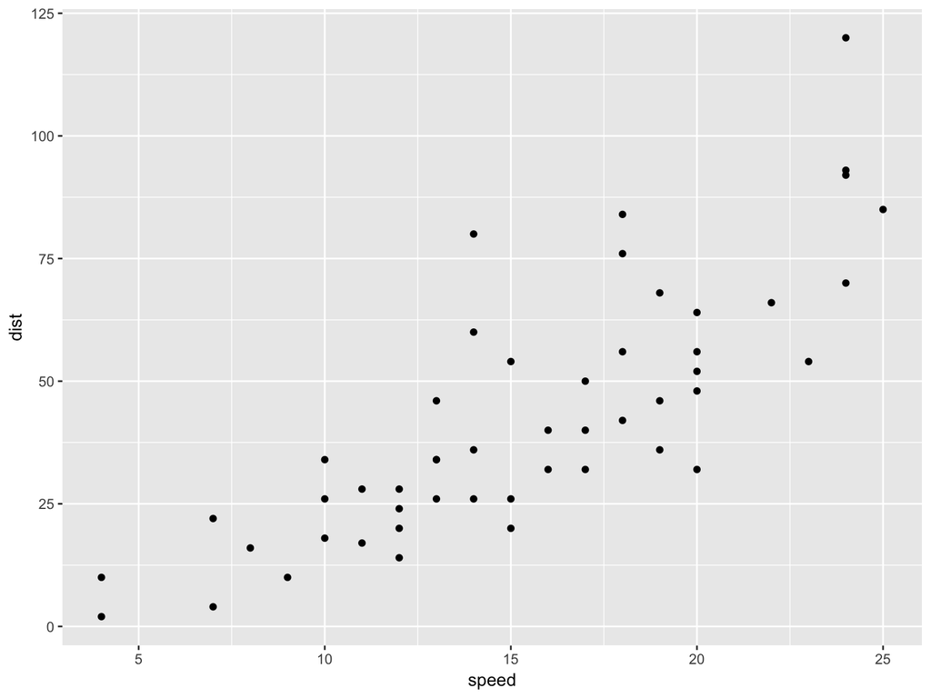

```r
ggplot(cars, aes(x = speed, y = dist)) +
  geom_point()
```

## 散佈圖（2）

- `+ ggtitle() + xlab() + ylab()` 編輯標題，X 軸名稱與 Y 軸名稱

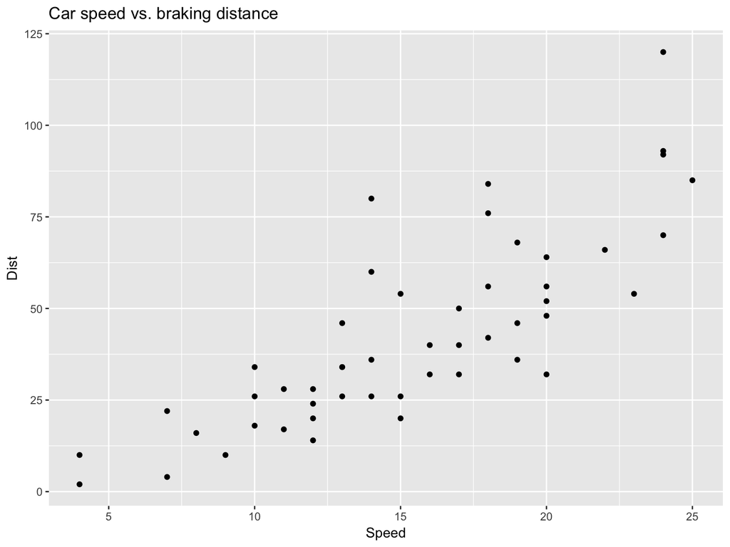

```r
ggplot(cars, aes(x = speed, y = dist)) +
  geom_point() +
  ggtitle("Car speed vs. braking distance") +
  xlab("Speed") +
  ylab("Dist")
```

## 散佈圖（3）

- `+ geom_smooth(method = )` 加上 fit line

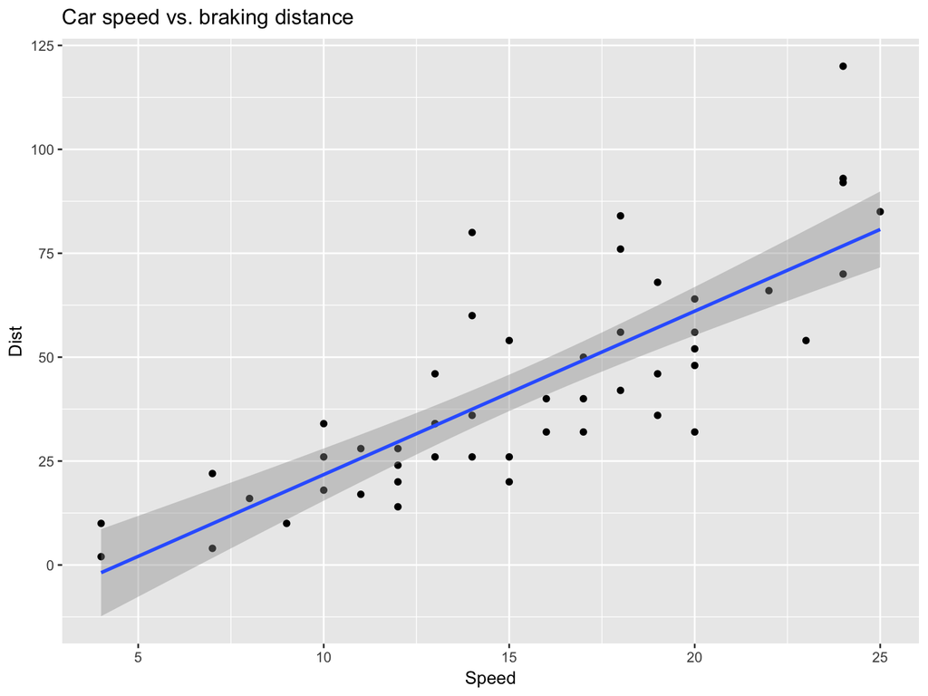

```r
ggplot(cars, aes(x = speed, y = dist)) +
  geom_point() +
  ggtitle("Car speed vs. braking distance") +
  xlab("Speed") +
  ylab("Dist") +
  geom_smooth(method = "lm")
```

## 散佈圖（4）

- `aes()` 中加入 `color =`

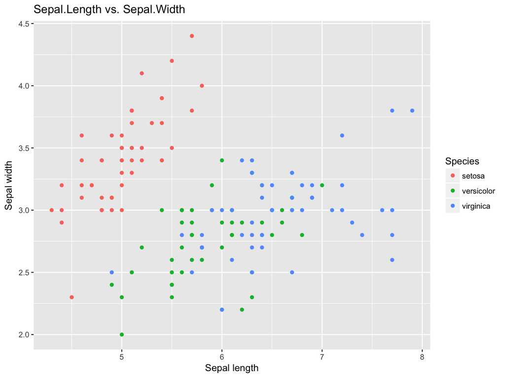

```r
str(iris)
ggplot(iris, aes(x = Sepal.Length, y = Sepal.Width, color = Species)) +
  geom_point() +
  ggtitle("Sepal.Length vs. Sepal.Width") +
  xlab("Sepal length") +
  ylab("Sepal width")
```

## 散佈圖（5）

- 練習使用 `ggplot2` 套件附的 `diamonds` 資料
- 畫出 `carat` 與 `price` 的散佈圖

```
library(ggplot2)

ggplot(___, aes(x = ___, y = ___)) +
  geom_point()
```

## 線圖

- `ggplot() + geom_line()` 繪製線圖

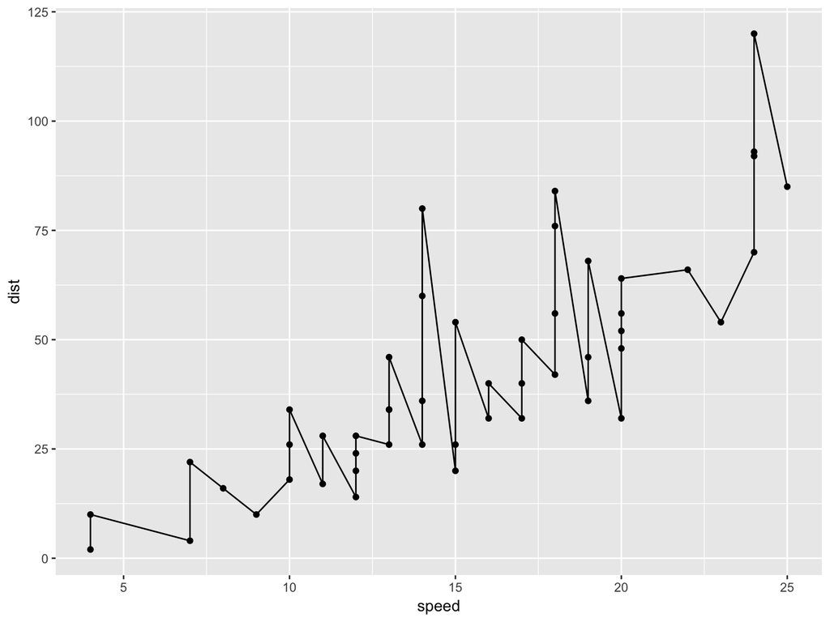

```r
ggplot(cars, aes(x = speed, y = dist)) +
  geom_point() +
  geom_line()
```

## 線圖（2）

- 線圖通常用來視覺化時間序列

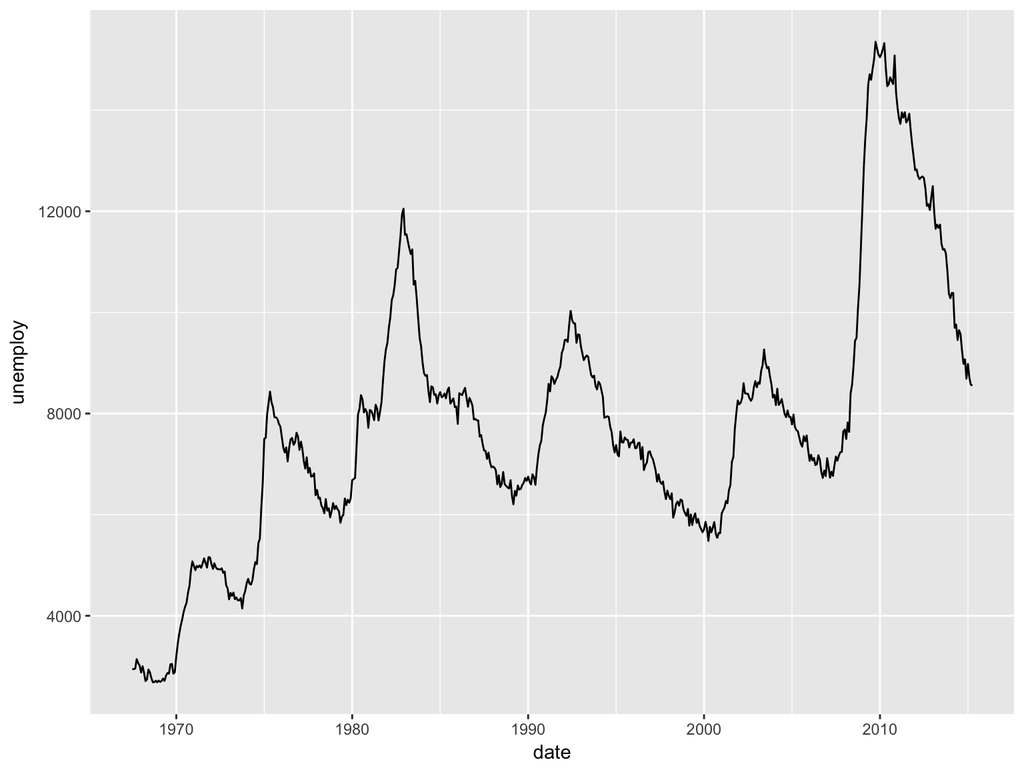

```r
head(economics)
ggplot(economics, aes(x = date, y = unemploy)) +
  geom_line()
```

## 直方圖

- `ggplot() + geom_histogram()` 繪製直方圖

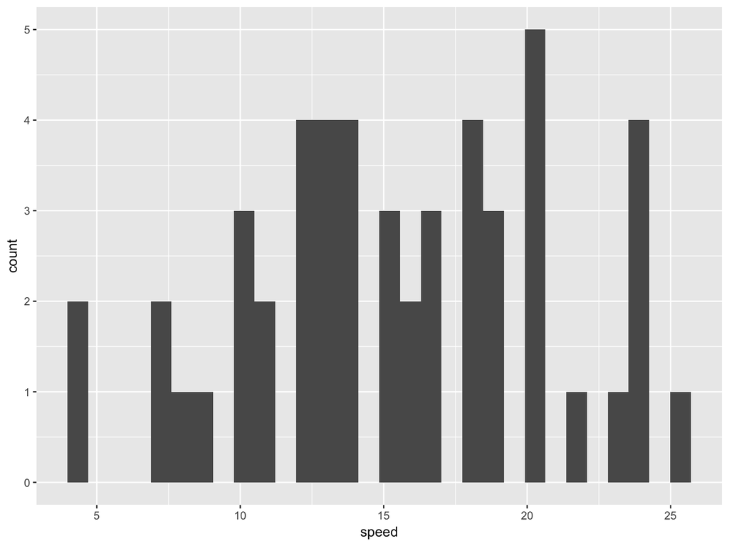

```r
ggplot(cars, aes(x = speed)) +
  geom_histogram()
```

## 直方圖（2）

- 透過 `facet_wrap()` 納入類別變數的展開

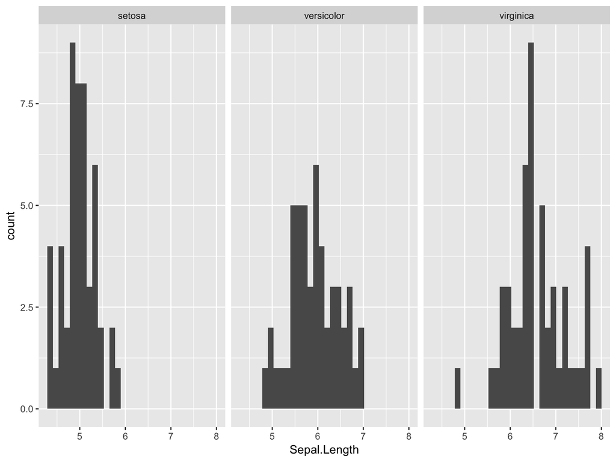

```r
ggplot(iris, aes(x = Sepal.Length)) +
  geom_histogram() +
  facet_wrap(~ Species) # 加入 ncol = 1 垂直展開
```

## 直方圖（3）

- 練習使用 `ggplot2` 套件附的 `diamonds` 資料
- 畫出 `carat` 的直方圖
- 選擇一個適當的 `binwidth`

```
library(ggplot2)

ggplot(___, aes(x = ___)) +
  geom_histogram(binwidth = ___)
```

## 盒鬚圖

- `ggplot() + geom_boxplot()` 繪製盒鬚圖

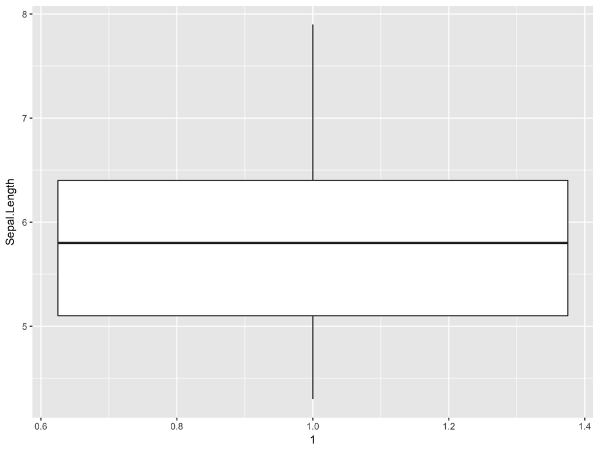

```r
ggplot(iris, aes(x = 1, y = Sepal.Length)) +
  geom_boxplot()
```

## 盒鬚圖（2）

- `aes()` 指定 `x =` 納入類別變數的展開

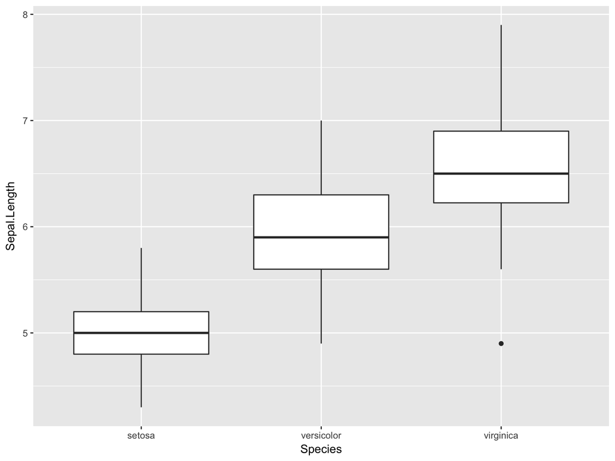

```r
ggplot(iris, aes(x = Species, y = Sepal.Length)) +
  geom_boxplot()
```

## 盒鬚圖（3）

- 練習使用 `ggplot2` 套件附的 `diamonds` 資料
- 畫出不同 `cut` 的 `price` 的盒鬚圖

```
library(ggplot2)

ggplot(___, aes(x = ___, y = ___)) +
  geom_boxplot()
```

## 函數圖

- `ggplot() + stat_function(fun = , geom = "line")`

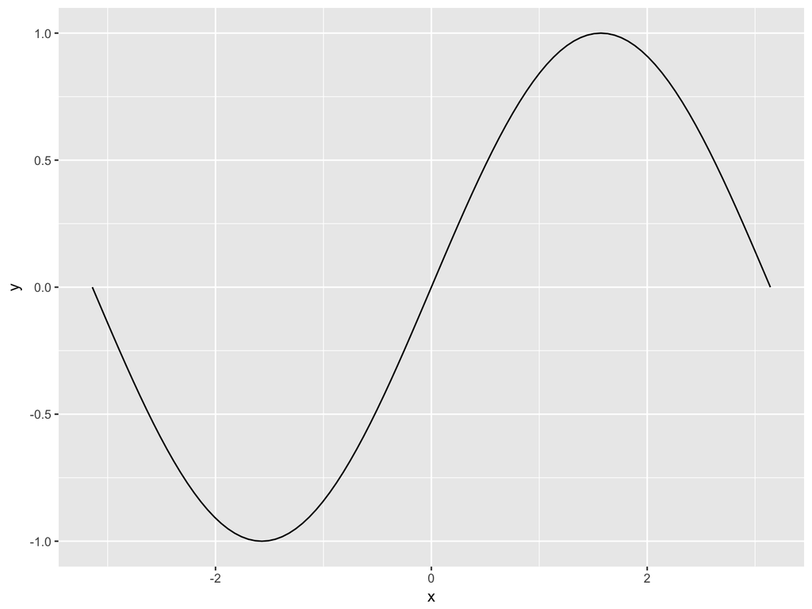

```r
sin_df <- data.frame(x = c(-pi, pi))
sin_df

ggplot(sin_df, aes(x = x)) +
  stat_function(fun = sin, geom = "line")
```

## 函數圖（2）

- 繪製自訂函數

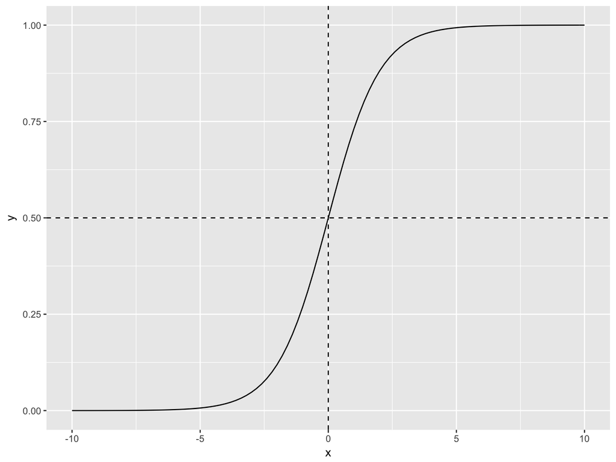

```r
sigmoid_func <- function(x){
  return(1 / (1 + exp(-x)))
}

sigmoid_df <- data.frame(x = c(-10, 10))
sigmoid_df

ggplot(sigmoid_df, aes(x = x)) +
  stat_function(fun = sigmoid_func, geom = "line") +
  geom_hline(yintercept = 0.5, lty = 2) +
  geom_vline(xintercept = 0, lty = 2)
```

## 長條圖

- `ggplot() + geom_bar()` 繪製長條圖

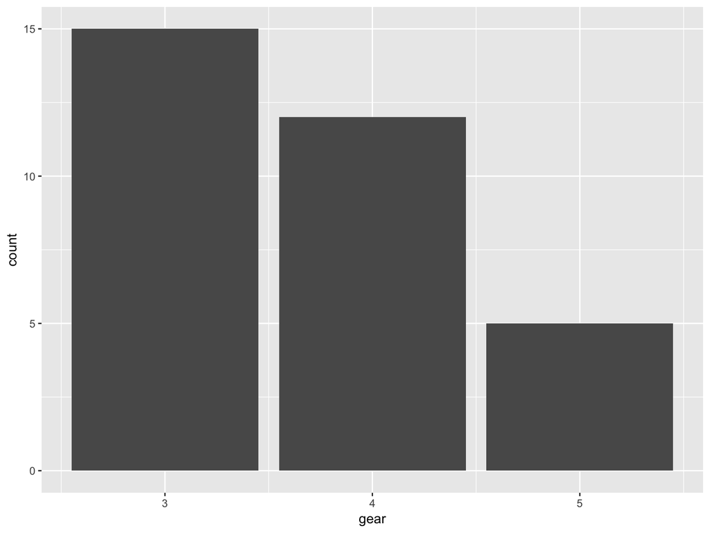

```r
ggplot(mtcars, aes(gear)) +
  geom_bar()
```

## 長條圖（2）

- `geom_bar(stat = "identity")` 可以呈現數值

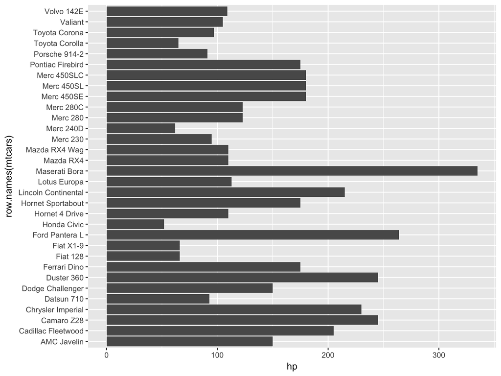

```r
ggplot(mtcars, aes(x = row.names(mtcars), y = hp)) +
  geom_bar(stat = "identity") + coord_flip()
```

## 長條圖（3）

- 練習使用 `ggplot2` 套件附的 `diamonds` 資料
- 看不同 `cut` 類型的數量

```
ggplot(___, aes(x = ___)) +
  geom_bar()
```

## 在一個畫布上畫多個圖形

- 使用 `gridExtra` 套件來幫忙
- `grid.arrange()` 函數

```
install.packages("gridExtra")
```

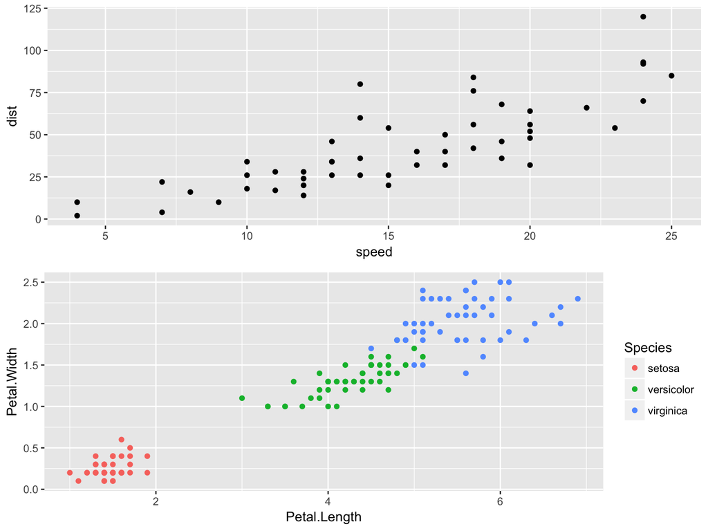

```r
library(gridExtra)

gg1 <- ggplot(cars, aes(x = speed, y = dist)) + geom_point()
gg2 <- ggplot(iris, aes(x = Petal.Length, y = Petal.Width, colour = Species)) + geom_point()
grid.arrange(gg1, gg2, nrow = 2)
```

## `ggplotly()` 加入互動性

- 使用 `plotly` 套件的 `ggplotly()` 函數

```
install.packages("plotly")
```

```r
library(plotly)
static_gg <- ggplot(iris, aes(x = Sepal.Length, y = Petal.Length, col = Species)) +
  geom_point()
ggplotly(static_gg)
```

## 圖形或資料的互動性

- [D3.js](https://d3js.org/)
- [Plotly](https://plot.ly/)
- [Shiny](https://shiny.rstudio.com/)

## 文件

- 沒事多看文件，多看文件沒事
- http://docs.ggplot2.org/current/index.html

## 期中作業

- 用一個 2x2 的畫布練習使用 ggplot2 繪製任意四個圖形